# Workshop 8 Fiancial Econometrics

Juan David Torres

Apr 14 2021

# Predictions with multiple regression models

Download data

```r
library(readxl)
# Dowload file
download.file("http://www.apradie.com/datos/datamx2020q4.xlsx", "dataw7.xlsx", mode="wb")
dataset <- read_excel("dataw7.xlsx")

# Download market data
library(quantmod)
getSymbols("^MXX", from="2000-01-01", to="2019-12-31", periodicity="monthly", src="yahoo")
```

[output not shown]

```
[1] "^MXX"
```

Merge the market returns

```r
# Collapse monthly data to quarterly data using the last value of each quarter

QMXX <- to.quarterly(MXX, indexAt = 'startof')

# Select the Adjusted price column
QMXX <- Ad(QMXX)
# Change column name
colnames(QMXX) <- c("IPC")
# Obtain market returns
QMXX$IPCrets <- diff(log(QMXX))
# Create a data frame object from QMXX
QMXX.df <- data.frame(quarter=index(QMXX), coredata(QMXX))

# Turn the common column to the same type
dataset$quarter <- as.Date(dataset$quarter)
# Many-to-1 merge
dataset <- merge(dataset, QMXX.df, by="quarter")

# Turn the data frame into panel data
library(plm)
paneldata <- pdata.frame(dataset, index = c("firmcode", "quarter"))
```

Calculation and windsorization of Book to market ratio

```r
# Keep only active firms
paneldata <- paneldata[paneldata$status == "active", ]

# Calculate bmr
paneldata$bookvalue <- paneldata$totalassets - paneldata$totalliabilities
paneldata$marketvalue<-paneldata$originalhistoricalstockprice*paneldata$sharesoutstanding
paneldata$bmr <- paneldata$bookvalue / paneldata$marketvalue

# Winsorize bmr with stataR
# We will use the winsorize function from the statar package.
# This function can work with panel data (the previous function from the robustHD
#   package cannot)
# You have to specifiy the minimum and the maximum percentile

library(statar)
paneldata$bmr_w <- winsorize(paneldata$bmr, probs = c(0.02,0.98))
```

```
1.20 % observations replaced at the bottom
1.20 % observations replaced at the top
```

Predictions with the predict lm function

```r
# The earnings per share  is the calculation of the earnings or profit divided by the number of shares of its stock. The resulting number serves as an indicator of a company's profitability.
# The earnings per share per price, is a way of valuing a company that measures its price with the earnings per share. It is used to determine the relative value of the company's share.
#Calculation of the EPS
paneldata$eps <- paneldata$ebit / paneldata$sharesoutstanding
```

4. Calculation earnings per share per price
5. winsorization of the values

```r
#Calculate epsp
paneldata$epsp <- paneldata$eps / paneldata$originalhistoricalstockprice

# Winsorize epsp
paneldata$epsp_w <- winsorize(paneldata$epsp, probs = c(0.02,0.98))
```

```
0.88 % observations replaced at the bottom
0.88 % observations replaced at the top
```

6. Running the multiple regression model for all firms in the las quarter 2019q4

```r
# Calculate cc returns for all returns
paneldata$stockreturn <- diff(log(paneldata$adjustedstockprice))
lastq <- as.data.frame(paneldata[(paneldata$quarter=="2019-10-01"),])

# Construct the regression model:
#   first write the dependent variable (y), then all explanatory variables
reg1 <- lm(stockreturn ~ epsp_w + bmr_w, data = lastq)
s_reg1 <- summary(reg1)
s_reg1
```

```
Call:
lm(formula = stockreturn ~ epsp_w + bmr_w, data = lastq)

Residuals:
     Min       1Q   Median       3Q      Max
-0.42027 -0.07916 -0.01485  0.07058  0.62443

Coefficients:
            Estimate Std. Error t value Pr(>|t|)
(Intercept)  0.05782    0.02709   2.134   0.0351 *
epsp_w      -0.01946    0.14011  -0.139   0.8898
bmr_w       -0.03106    0.01915  -1.622   0.1077
---
Signif. codes:  0 ‘***’ 0.001 ‘**’ 0.01 ‘*’ 0.05 ‘.’ 0.1 ‘ ’ 1

Residual standard error: 0.1584 on 110 degrees of freedom
  (39 observations deleted due to missingness)
Multiple R-squared:  0.02496,   Adjusted R-squared:  0.007232
F-statistic: 1.408 on 2 and 110 DF,  p-value: 0.249
```

7. Manual Prediction

```r
manual_pred = 0.05* s_reg1$coefficients[2,1]+ 0.8*s_reg1$coefficients[3,1]+ s_reg1$coefficients[1,1]
manual_pred
```

```
[1] 0.03199618
```

8. Prediction using predict lm

```r
new_x <- data.frame(epsp_w=c(0.05), bmr_w=c(0.8))
predict.lm(reg1, newdata = new_x)
```

```
         1
0.03199618
```

Confidence interval 0.95

```r
pr_reg1 <- predict.lm(reg1, new_x, interval = "confidence")
pr_reg1
```

```
         fit          lwr        upr
1 0.03199618 -0.002305707 0.06629807
```

Yes it got the same prediction than manually.

Q: Interpret the 95% confidence interval for the prediction. A: Given the linear regression coefficients that where calculated it can be said that if the book to market ratio is 0.8 and the earnings per share per price is 0.05 the there is 95% confidence that the value of the stock return is between -0.00230 and 0.06629 which means that there is no enough statistical evidence that given the values of espp and bmr the stock price will be positive.

```r
# Join both objects in order to have a better perception
pr_reg1.df <- cbind(new_x, pr_reg1)
pr_reg1.df
```

|  | epsp_w | bmr_w | fit | lwr | upr |
| --- | --- | --- | --- | --- | --- |
| 1 | 0.05 | 0.8 | 0.03199618 | -0.002305707 | 0.06629807 |

9. Multiple regression model for market return and BMR

```r
# Construct the model
reg2 <- lm(stockreturn ~ IPCrets + bmr_w, data = paneldata)
s_reg2 <- summary(reg2)
s_reg2
```

```
Call:
lm(formula = stockreturn ~ IPCrets + bmr_w, data = paneldata)

Residuals:
     Min       1Q   Median       3Q      Max
-1.26380 -0.07630 -0.00448  0.07449  1.56551

Coefficients:
             Estimate Std. Error t value Pr(>|t|)
(Intercept)  0.032240   0.002972   10.85   <2e-16 ***
IPCrets      0.830298   0.023419   35.45   <2e-16 ***
bmr_w       -0.032087   0.002315  -13.86   <2e-16 ***
---
Signif. codes:  0 ‘***’ 0.001 ‘**’ 0.01 ‘*’ 0.05 ‘.’ 0.1 ‘ ’ 1

Residual standard error: 0.1675 on 7096 degrees of freedom
  (5061 observations deleted due to missingness)
Multiple R-squared:  0.1712,    Adjusted R-squared:  0.171
F-statistic: 733.1 on 2 and 7096 DF,  p-value: < 2.2e-16
```

95% confidence

```r
new_x2 <- data.frame(bmr_w=0.8, IPCrets = 1)
pr_reg2 <- predict.lm(reg2, new_x2, interval = "confidence")
pr_reg2
```

```
        fit       lwr       upr
1 0.8368685 0.7916157 0.8821213
```

Join both

```r
pr_reg2.df <- cbind(new_x2, pr_reg2)
pr_reg2.df
```

|  | bmr_w | IPCrets | fit | lwr | upr |
| --- | --- | --- | --- | --- | --- |
| 1 | 0.8 | 1 | 0.8368685 | 0.7916157 | 0.8821213 |

1. If the market return is 100% and the BMR is 0.8 then it can be said with a 95% confidence that the stock return could go between 79.1615% and 88.2121%. The prediction is 83.6868% for those values.
2. Prediction

```r
new_x2b <- data.frame(IPCrets=seq(from=-0.02, to=0.02, by=0.01), bmr_w=1)
pr_reg2b <- predict.lm(reg2, new_x2b, interval = "confidence")
pr_reg2b
```

```
            fit          lwr          upr
1 -0.0164523682 -0.020726696 -0.012178040
2 -0.0081493921 -0.012259322 -0.004039462
3  0.0001535839 -0.003838245  0.004145413
4  0.0084565599  0.004532355  0.012380765
5  0.0167595360  0.012849856  0.020669215
```

```r
pr_reg2b.df <- cbind(new_x2b, pr_reg2b)
colnames(pr_reg2b.df) <- c("IPCrets", "bmr_w", "Stockreturn", "lwr", "upr")
pr_reg2b.df
```

|  | IPCrets | bmr_w | Stockreturn | lwr | upr |
| --- | --- | --- | --- | --- | --- |
| 1 | -0.02 | 1 | -0.0164523682 | -0.020726696 | -0.012178040 |
| 2 | -0.01 | 1 | -0.0081493921 | -0.012259322 | -0.004039462 |
| 3 | 0.00 | 1 | 0.0001535839 | -0.003838245 | 0.004145413 |
| 4 | 0.01 | 1 | 0.0084565599 | 0.004532355 | 0.012380765 |
| 5 | 0.02 | 1 | 0.0167595360 | 0.012849856 | 0.020669215 |

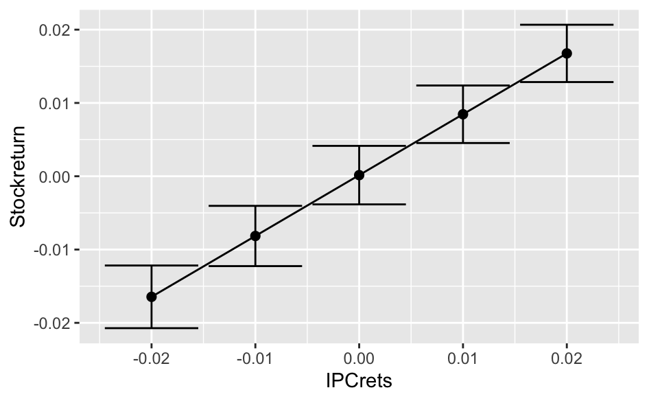

```r
library(ggplot2)
ggplot(pr_reg2b.df, aes(x = IPCrets, y=Stockreturn))+
  geom_point(size = 2) + geom_line() +
  geom_errorbar(aes(ymax = upr, ymin=lwr))
```

```r
library(prediction)
prediction(reg2, at = list(IPCrets=seq(from=-0.02, to=0.02, by=0.01), bmr_w=1))
```

```
Data frame with 35495 predictions from
 lm(formula = stockreturn ~ IPCrets + bmr_w, data = paneldata)
with average predictions:
```

| IPCrets | bmr_w | x |
| --- | --- | --- |
| -0.02 | 1 | -0.0164523682 |
| -0.01 | 1 | -0.0081493921 |
| 0.00 | 1 | 0.0001535839 |
| 0.01 | 1 | 0.0084565599 |
| 0.02 | 1 | 0.0167595360 |

Interpretation: From the output data it can be seen that when the BMR is constantly 1 and the market returns goes from -0.02 to 0.02 by a rate of 0.01 the stock return increases linearly, the stock return 95% confidence interval is spaced consistently between each of the stock returns predicted.

# Tiem series pre-fix of variables and condtionals in regression models

1. Two regression models to examine wther the BMRw and the return influence a) the future stock return one quarter later and b) the future stock return one year later

Use plm to do the linear regression model

```r
# Load plm
library(plm)

# Use the lag() function with -1 indicating to go forward 1 period
model1 <- plm(lag(stockreturn, -1) ~ IPCrets + bmr_w, data=paneldata, model="pooling")
s_model1 <- summary(model1)
s_model1
```

```
Pooling Model

Call:
plm(formula = lag(stockreturn, -1) ~ IPCrets + bmr_w, data = paneldata,
    model = "pooling")

Unbalanced Panel: n = 146, T = 1-78, N = 7039

Residuals:
      Min.    1st Qu.     Median    3rd Qu.       Max.
-1.3348414 -0.0774005 -0.0027878  0.0818477  1.4644899

Coefficients:
             Estimate Std. Error t-value  Pr(>|t|)
(Intercept) 0.0017384  0.0032410  0.5364    0.5917
IPCrets     0.2748376  0.0253327 10.8491 < 2.2e-16 ***
bmr_w       0.0114935  0.0025282  4.5461 5.557e-06 ***
---
Signif. codes:  0 ‘***’ 0.001 ‘**’ 0.01 ‘*’ 0.05 ‘.’ 0.1 ‘ ’ 1

Total Sum of Squares:    237.61
Residual Sum of Squares: 233.09
R-Squared:      0.019058
Adj. R-Squared: 0.018779
F-statistic: 68.3469 on 2 and 7036 DF, p-value: < 2.22e-16
```

Can be constructed also like this :

```r
model1a<-plm(stockreturn ~ lag(IPCrets) + lag(bmr_w), data = paneldata, model="pooling")
summary(model1a)
```

```
Pooling Model

Call:
plm(formula = stockreturn ~ lag(IPCrets) + lag(bmr_w), data = paneldata,
    model = "pooling")

Unbalanced Panel: n = 146, T = 1-78, N = 7039

Residuals:
      Min.    1st Qu.     Median    3rd Qu.       Max.
-1.3348414 -0.0774005 -0.0027878  0.0818477  1.4644899

Coefficients:
              Estimate Std. Error t-value  Pr(>|t|)
(Intercept)  0.0017384  0.0032410  0.5364    0.5917
lag(IPCrets) 0.2748376  0.0253327 10.8491 < 2.2e-16 ***
lag(bmr_w)   0.0114935  0.0025282  4.5461 5.557e-06 ***
---
Signif. codes:  0 ‘***’ 0.001 ‘**’ 0.01 ‘*’ 0.05 ‘.’ 0.1 ‘ ’ 1

Total Sum of Squares:    237.61
Residual Sum of Squares: 233.09
R-Squared:      0.019058
Adj. R-Squared: 0.018779
F-statistic: 68.3469 on 2 and 7036 DF, p-value: < 2.22e-16
```

2. Model 2
1. BMRw and ESPSP one year later

```r
model2 <- plm(lag(stockreturn, -4) ~ bmr_w + epsp_w, data = paneldata, model="pooling")
s_model2 <- summary(model2)
s_model2
```

```
Pooling Model

Call:
plm(formula = lag(stockreturn, -4) ~ bmr_w + epsp_w, data = paneldata,
    model = "pooling")

Unbalanced Panel: n = 126, T = 1-76, N = 4756

Residuals:
      Min.    1st Qu.     Median    3rd Qu.       Max.
-1.3128451 -0.0740470 -0.0028452  0.0789605  1.4889600

Coefficients:
              Estimate Std. Error t-value Pr(>|t|)
(Intercept)  0.0019973  0.0041118  0.4857  0.62717
bmr_w        0.0089931  0.0035967  2.5004  0.01244 *
epsp_w      -0.0066547  0.0343372 -0.1938  0.84634
---
Signif. codes:  0 ‘***’ 0.001 ‘**’ 0.01 ‘*’ 0.05 ‘.’ 0.1 ‘ ’ 1

Total Sum of Squares:    157.48
Residual Sum of Squares: 157.26
R-Squared:      0.0013965
Adj. R-Squared: 0.00097633
F-statistic: 3.3235 on 2 and 4753 DF, p-value: 0.03611
```

When the BMR and EPSP are 0 then the stock returns will be approximately 0.0019973. After considering the effect of the epsp there is enough statistical evidence to say that there is a positive relation between the bmr and the stock returns of one year after. After considering the effect of the bmr there is not enough statistical evidence that the relation between the epsp is negative which means that in average the relation is negative but it can also be positive.

2. Predict the stock return of firms when BMRw moves from 0.6 to 1.6

```r
newx_model2 <- data.frame(bmr_w = seq(from=0.6, to=1.6, by=0.1), epsp_w=mean(paneldata$epsp_w, na.rm=TRUE))
pr1_model2 <- prediction_summary(model=model2, at=newx_model2,level=0.95)
colnames(pr1_model2) <- c("bmr_w","epsp_w", "Predicted_return")
var_b0 <- s_model2$coefficients[1,2]^2
var_b1 <- s_model2$coefficients[2,2]^2
var_b2 <- s_model2$coefficients[3,2]^2
cov_coeff <- cov(matrix(c(s_model2$coefficients[1,1], s_model2$coefficients[2,1],s_model2$coefficients[3,1])))
pr1_model2$SE <- sqrt(var_b0 + pr1_model2$bmr_w^2*var_b1 +pr1_model2$epsp_w^2*var_b2 + 2*cov_coeff)
```

```
Recycling array of length 1 in vector-array arithmetic is deprecated.
  Use c() or as.vector() instead.
```

```r
pr1_model2$lwr <- pr1_model2$Predicted_return - 2*pr1_model2$SE
pr1_model2$upr <- pr1_model2$Predicted_return + 2*pr1_model2$SE

pr1_model2
```

|  | bmr_w | epsp_w | Predicted_return | None | None | None | None | None | SE | lwr | upr |
| --- | --- | --- | --- | --- | --- | --- | --- | --- | --- | --- | --- |
| 1 | 0.6 | 0.06349375 | 0.006970645 | NA | NA | NA | NA | NA | 0.01221481 | -0.01745898 | 0.03140027 |
| 2 | 0.7 | 0.06349375 | 0.007869954 | NA | NA | NA | NA | NA | 0.01228346 | -0.01669697 | 0.03243687 |
| 3 | 0.8 | 0.06349375 | 0.008769263 | NA | NA | NA | NA | NA | 0.01236219 | -0.01595513 | 0.03349365 |
| 4 | 0.9 | 0.06349375 | 0.009668572 | NA | NA | NA | NA | NA | 0.01245083 | -0.01523308 | 0.03457022 |
| 5 | 1.0 | 0.06349375 | 0.010567881 | NA | NA | NA | NA | NA | 0.01254914 | -0.01453040 | 0.03566617 |
| 6 | 1.1 | 0.06349375 | 0.011467190 | NA | NA | NA | NA | NA | 0.01265692 | -0.01384665 | 0.03678103 |
| 7 | 1.2 | 0.06349375 | 0.012366499 | NA | NA | NA | NA | NA | 0.01277392 | -0.01318134 | 0.03791434 |
| 8 | 1.3 | 0.06349375 | 0.013265808 | NA | NA | NA | NA | NA | 0.01289989 | -0.01253397 | 0.03906558 |
| 9 | 1.4 | 0.06349375 | 0.014165117 | NA | NA | NA | NA | NA | 0.01303457 | -0.01190402 | 0.04023425 |
| 10 | 1.5 | 0.06349375 | 0.015064425 | NA | NA | NA | NA | NA | 0.01317769 | -0.01129095 | 0.04141980 |

[output cut: 1 more lines]

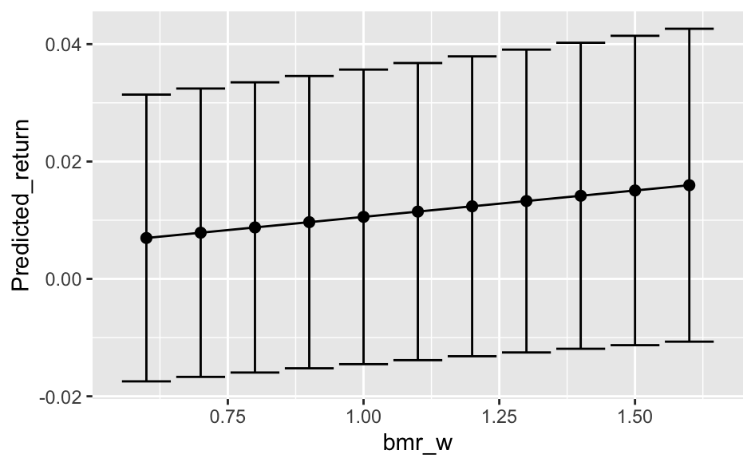

```r
ggplot(pr1_model2, aes(x = bmr_w, y=Predicted_return))+
  geom_point(size = 2) + geom_line() +
  geom_errorbar(aes(ymax = upr, ymin=lwr))
```

The increase of 0.1 in the BMRw doesn’t affect that much the stock return predicted which means that the coefficient of BMRw is not very high and can be seen in the slope of the graph. The 95% confidence interval covers most of the predicted returns and goes from negative to positive returns.